# BiPOCD_Modeling_1: Linear models for classification

Sebastian Sauer

21 Juli 2016

Define whether we work.

```r
write_to_file <- TRUE
recompute <- FALSE
test_it <- TRUE
```

# 1 Modeling BiPOCD

We load the data that has been prepared in the previous step. Dimension of the dataset (r/c):

```r
data_class <- read_csv("raw_data/data_mod3.csv")
data_class$responder_3m_f <- factor(data_class$responder_3m_f)
dim(data_class)
```

```
## [1] 61 46
```

```r
source("analysis/functions/save_model_results.R")
```

# 2 Basic classification (dichotomous outcome)

As we have two outcomes, one dichotomous and one metric, we can both do classification and regression. Let’s look at classification first.

Before I forget: we need to exclude the metric outcome variable `CYBOCS_3m`.

```r
exclude_metric_outcome <- function(data_df = data_class){
  if ("CYBOCS_3m" %in% names(data_df)) {
    data_df <- dplyr::select(data_df, -CYBOCS_3m)
    message("CYBOCS_3m has been excluded from the data set\n")
  }else {
   message("CYBOCS_3m was not in data frame")
  }
  return(data_df)
}

data_class <- exclude_metric_outcome(data_class)
```

Number of columns in `data_class`: 45.

```r
test_split_data <- function(data_df = data_class){
  cat("Class of DV:\n")
  print(str(data_df$responder_3m_f))
  print(str(data_df$responder_3m_f))
  print(str(data_df$responder_3m_f))


  if ("CYBOCS_3m" %in% names(data_df)) warning("CYBOCS_3m is *in* test sample")
  if (!("CYBOCS_3m" %in% names(data_df))) message("CYBOCS_3m is NOT in test sample")
  message("done")
}

test_split_data(data_class)
```

```
## Class of DV:
##  Factor w/ 2 levels "0","1": 2 1 1 1 1 1 2 2 1 2 ...
## NULL
##  Factor w/ 2 levels "0","1": 2 1 1 1 1 1 2 2 1 2 ...
## NULL
##  Factor w/ 2 levels "0","1": 2 1 1 1 1 1 2 2 1 2 ...
## NULL
```

```r
set.seed(42)
trainIndex <- createDataPartition(data_class$responder_3m_f, p = .8,
                                  list = FALSE,
                                  times = 1)

train_sample <- data_class[trainIndex, ]
test_sample <- data_class[-trainIndex, ]




if (test_it ==  TRUE) test_split_data()
```

```
## Class of DV:
##  Factor w/ 2 levels "0","1": 2 1 1 1 1 1 2 2 1 2 ...
## NULL
##  Factor w/ 2 levels "0","1": 2 1 1 1 1 1 2 2 1 2 ...
## NULL
##  Factor w/ 2 levels "0","1": 2 1 1 1 1 1 2 2 1 2 ...
## NULL
```

## 2.1 Linear Model with all predictors included (probably not identified)

Let’s fit a linear logistic model. The model showed some problems with factor variables that have sparsely populated levels. Additionally, the ratio of variables to observations is not really nice. We probably will not arrive anywhere with this model.

```r
do_glmfit1 <- function(data_df = data_class, n_reps = 5){

  ctrl <- trainControl(method = "repeatedcv",
                       repeats = n_reps,
                       number = 10)

  glmfit1 <- train(factor(responder_3m_f) ~ .,
                   data = data_df,
                   method = "glm",
                   trControl = ctrl)

  return(glmfit1)

}


expect_true(is.factor(train_sample$responder_3m_f))

glmfit1 <- do_glmfit1(train_sample)
summary(glmfit1)
```

```
##
## Call:
## NULL
##
## Deviance Residuals:
##         X1          X2          X3          X4          X5          X6
##  1.100e-06  -5.957e-07  -1.105e-06  -1.146e-06   9.191e-07  -2.322e-06
##         X7          X8          X9         X10         X11         X12
##  2.826e-06   2.409e-06  -2.110e-08   3.228e-06   2.907e-06  -2.110e-08
##        X13         X14         X15         X16         X17         X18
##  3.098e-06   3.215e-06  -4.676e-06   3.652e-06  -3.962e-06  -1.184e-06
##        X19         X20         X21         X22         X23         X24
## -3.361e-06  -3.531e-06  -1.509e-06  -2.910e-06   3.203e-06   1.343e-06
##        X25         X26         X27         X28         X29         X30
##  2.177e-06  -3.159e-06   1.247e-06   4.435e-06  -3.007e-06   3.799e-06
##        X31         X32         X33         X34         X35         X36
##  3.260e-06   3.359e-06  -2.700e-06   2.941e-06   1.791e-06  -1.204e-06
##        X37         X38         X39         X40         X41         X42
##  2.584e-06   2.110e-08   2.208e-06  -3.087e-06  -3.251e-06   2.455e-06
##        X43         X44         X45         X46         X47         X48
##  1.685e-06  -3.414e-06   2.110e-08  -2.321e-06   2.409e-06   2.436e-06
##        X49
##  1.134e-06
##
## Coefficients: (1 not defined because of singularities)
##                               Estimate Std. Error z value Pr(>|z|)
## (Intercept)                 -5.522e+01  6.525e+06       0        1
## CYBOCS_pre_OBS              -8.787e+00  1.614e+05       0        1
## CYBOCS_pre_COMP              3.392e+00  1.336e+05       0        1
## CYBOCS_pre_insight          -1.429e+01  3.124e+05       0        1
## CYBOCS_pre_avoid             1.020e+00  2.009e+05       0        1
## ChOCI_R_C_sumsym_PRE         3.679e+00  6.264e+04       0        1
## ChOCI_R_C_sumimp_PRE         3.001e-01  4.902e+04       0        1
## EWSASC_sum_PRE              -1.123e+00  6.381e+04       0        1
## SCAS_S_C_sum_PRE            -4.479e+00  7.816e+04       0        1
## CDI_S_sum_PRE                4.006e+00  6.417e+04       0        1
## ChOCI_R_P_sumsym_PRE         1.629e+00  6.762e+04       0        1
## ChOCI_R_P_sumimp_PRE         5.305e-02  6.811e+04       0        1
## FAS_PR_sum_PRE               6.830e-01  5.083e+04       0        1
## EWSASP_sum_PRE               7.052e-01  6.939e+04       0        1
```

[output cut: 24 more lines]

```
## OCD_treatm_expnone           6.937e+01  2.361e+06       0        1
## CGI_S_pre                    3.146e+01  3.891e+05       0        1
## checking                     7.190e+00  2.954e+05       0        1
## obsessions                   3.687e+01  3.236e+05       0        1
## contamination               -2.386e+01  9.968e+05       0        1
## symmetry                    -2.685e+01  9.784e+05       0        1
## CBT_OCD                      7.826e+01  2.083e+06       0        1
##
## (Dispersion parameter for binomial family taken to be 1)
##
##     Null deviance: 6.6925e+01  on 48  degrees of freedom
## Residual deviance: 3.3432e-10  on  5  degrees of freedom
## AIC: 88
##
## Number of Fisher Scoring iterations: 25
```

```r
print(glmfit1)
```

```
## Generalized Linear Model
##
## 49 samples
## 44 predictors
##  2 classes: '0', '1'
##
## No pre-processing
## Resampling: Cross-Validated (10 fold, repeated 5 times)
## Summary of sample sizes: 44, 44, 45, 44, 44, 45, ...
## Resampling results:
##
##   Accuracy  Kappa
##   0.596     0.1832534
##
##
```

```r
confusionMatrix(glmfit1)
```

```
## Cross-Validated (10 fold, repeated 5 times) Confusion Matrix
##
## (entries are percentual average cell counts across resamples)
##
##           Reference
## Prediction    0    1
##          0 27.8 25.7
##          1 15.1 31.4
##
##  Accuracy (average) : 0.5918
```

```r
# undebug(save_model_results)
mod_results$glmfit1 <- save_model_results(glmfit1)
```

```
## Computing predictiong. Predicted values are:
```

```
##  [1] 1 0 0 0 1 1 1 1 0 1 0 0
## Levels: 0 1
```

```
## confusion matrix for predicted values and factual values:
```

```
## Confusion Matrix and Statistics
##
##           Reference
## Prediction 0 1
##          0 2 4
##          1 3 3
##
##                Accuracy : 0.4167
##                  95% CI : (0.1517, 0.7233)
##     No Information Rate : 0.5833
##     P-Value [Acc > NIR] : 0.9274
##
##                   Kappa : -0.1667
##  Mcnemar's Test P-Value : 1.0000
##
##             Sensitivity : 0.4000
##             Specificity : 0.4286
##          Pos Pred Value : 0.3333
##          Neg Pred Value : 0.5000
##              Prevalence : 0.4167
##          Detection Rate : 0.1667
##    Detection Prevalence : 0.5000
##       Balanced Accuracy : 0.4143
##
##        'Positive' Class : 0
##
## glm variable importance
##
##   only 20 most important variables shown (out of 43)
##
##                               Overall
## obsessions                  1.139e-04
## CGI_S_pre                   8.084e-05
## TourettesTics               6.882e-05
## CDI_S_sum_PRE               6.242e-05
## ChOCI_R_C_sumsym_PRE        5.874e-05
## SCAS_S_C_sum_PRE            5.731e-05
## CYBOCS_pre_OBS              5.444e-05
## CYBOCS_pre_insight          4.574e-05
## ADHD                        4.093e-05
## CBT_OCD                     3.757e-05
## SocialPhob                  3.635e-05
## GAD                         3.447e-05
## numberdiagnos               3.373e-05
## distance                    3.322e-05
## age                         3.259e-05
## yearswithOCD                3.123e-05
## OCD_treatm_expnone          2.938e-05
## Education_parentHigh.school 2.938e-05
## OCDonset                    2.842e-05
## symmetry                    2.744e-05
```

```r
#
# dummy <- predict(glmfit1, test_sample)
#
# confusionMatrix(dummy, test_sample$responder_3m_f)
# str(test_sample$responder_3m_f)
```

Classification rate was …bad…? But now look at the variable importance. Note:

> Linear Models: the absolute value of the t–statistic for each model parameter is used.

(From caret help `varimp`.)

```r
mod_results$glmfit1$varimp[[1]] %>%
  as_tibble %>%
  #dplyr::select(everything()) %>%
  rownames_to_column %>%
  arrange(desc(Overall))%>%
  top_n(5) %>%
  kable
```

| rowname | Overall |
| --- | --- |
| obsessions | 0.0001139 |
| CGI_S_pre | 0.0000808 |
| TourettesTics | 0.0000688 |
| CDI_S_sum_PRE | 0.0000624 |
| ChOCI_R_C_sumsym_PRE | 0.0000587 |

Only top-5 shown.

Let’s look at McFadden’s pseudo R^2. Note that we here too have to fit the model using the train sample, but judge perfomance on the test sample.

```r
glmfit1 <- glm(responder_3m_f ~ .,
               data = train_sample,
               family = "binomial",
               control = list(maxit = 50))
print(pR2(glmfit1))
```

```
##           llh       llhNull            G2      McFadden          r2ML
## -1.671552e-10 -3.346250e+01  6.692499e+01  1.000000e+00  7.448277e-01
##          r2CU
##  1.000000e+00
```

Here, the algorithm tells us that we ran into problems; it may well be that we have too many predictors. MacFadden’s R^2 is 1; appears too good to be true. We should not consider this model any further.

Although not undebated among statisticians, let’s try a stepwise regression instead (Gelman detests it, but Hastie/Tibshirani seem to be ok with it)

## 2.2 Stepwise LM

```r
do_glmfit2 <- function(save_results = FALSE, data_df = train_sample, n_repeats = 10,
                       n_folds = 10){

  ctrl <- caret::trainControl(method = "repeatedcv",
                       repeats = n_repeats,
                       number = n_folds)  # folds

  if ("ID" %in% names(data_df)) data_df <- dplyr::select(data_df, -ID)

  glmfit2 <- caret::train(responder_3m_f ~ .,
                   data = data_df,
                   method = "glmStepAIC",
                   trControl = ctrl,
                   verbose = TRUE)   # takes some minutes! *expensive*


  if (save_results == TRUE) {
    save(glmfit2, file = "data_objects/glmfit2.Rda")
    cat("writing object to file (in working directory)\n")
  }

  return(glmfit2)
}
```

```r
glmfit2_pred <- predict(glmfit2, newdata = test_sample)
# length(glmfit2_pred)



mod_results$glmfit2$fit <- glmfit2
(mod_results$glmfit2$confusion_matrix <- confusionMatrix(data = glmfit2_pred, test_sample$responder_3m_f))
```

```
## Confusion Matrix and Statistics
##
##           Reference
## Prediction 0 1
##          0 1 4
##          1 4 3
##
##                Accuracy : 0.3333
##                  95% CI : (0.0992, 0.6511)
##     No Information Rate : 0.5833
##     P-Value [Acc > NIR] : 0.9794
##
##                   Kappa : -0.3714
##  Mcnemar's Test P-Value : 1.0000
##
##             Sensitivity : 0.20000
##             Specificity : 0.42857
##          Pos Pred Value : 0.20000
##          Neg Pred Value : 0.42857
##              Prevalence : 0.41667
##          Detection Rate : 0.08333
##    Detection Prevalence : 0.41667
##       Balanced Accuracy : 0.31429
##
##        'Positive' Class : 0
##
```

```r
mod_results$glmfit2$name <- "glmfit2"
# mod_results$glmfit2$varimp <- varImp(glmfit2, scale = FALSE)
```

Kappa was negative. We should not consider this model further.

## 2.3 Linear model with univariate feature selection.

The idea here is: Submit all variables to a multiple regression where the t-Test shows “substantial differences” with the outcome groups.

```r
data_glm3 <- dplyr::select(train_sample, yearswithOCD, OCDonset, CGI_S_pre, CYBOCS_pre_avoid, responder_3m_f)

expect_true(is.factor(train_sample$responder_3m_f))

glmfit3 <- do_glmfit1(data_df = data_glm3)
summary(glmfit3)
```

```
##
## Call:
## NULL
##
## Deviance Residuals:
##     Min       1Q   Median       3Q      Max
## -2.2997  -0.9313   0.1468   0.8983   1.6471
##
## Coefficients:
##                  Estimate Std. Error z value Pr(>|z|)
## (Intercept)       -0.9436     2.9837  -0.316   0.7518
## yearswithOCD       0.1366     0.2653   0.515   0.6066
## OCDonset          -0.3179     0.2114  -1.504   0.1327
## CGI_S_pre          1.1571     0.6715   1.723   0.0848 .
## CYBOCS_pre_avoid   0.1682     0.3846   0.437   0.6619
## ---
## Signif. codes:  0 '***' 0.001 '**' 0.01 '*' 0.05 '.' 0.1 ' ' 1
##
## (Dispersion parameter for binomial family taken to be 1)
##
##     Null deviance: 66.925  on 48  degrees of freedom
## Residual deviance: 51.929  on 44  degrees of freedom
## AIC: 61.929
##
## Number of Fisher Scoring iterations: 5
```

```r
print(glmfit3)
```

```
## Generalized Linear Model
##
## 49 samples
##  4 predictor
##  2 classes: '0', '1'
##
## No pre-processing
## Resampling: Cross-Validated (10 fold, repeated 5 times)
## Summary of sample sizes: 44, 44, 44, 45, 44, 43, ...
## Resampling results:
##
##   Accuracy   Kappa
##   0.6743333  0.3453014
##
##
```

```r
confusionMatrix(glmfit3)
```

```
## Cross-Validated (10 fold, repeated 5 times) Confusion Matrix
##
## (entries are percentual average cell counts across resamples)
##
##           Reference
## Prediction    0    1
##          0 29.8 19.6
##          1 13.1 37.6
##
##  Accuracy (average) : 0.6735
```

```r
mod_results$glmfit3 <- save_model_results(glmfit3)
```

```
## Computing predictiong. Predicted values are:
```

```
##  [1] 0 0 1 0 1 0 1 0 0 1 1 1
## Levels: 0 1
```

```
## confusion matrix for predicted values and factual values:
```

```
## Confusion Matrix and Statistics
##
##           Reference
## Prediction 0 1
##          0 3 3
##          1 2 4
##
##                Accuracy : 0.5833
##                  95% CI : (0.2767, 0.8483)
##     No Information Rate : 0.5833
##     P-Value [Acc > NIR] : 0.6202
##
##                   Kappa : 0.1667
##  Mcnemar's Test P-Value : 1.0000
##
##             Sensitivity : 0.6000
##             Specificity : 0.5714
##          Pos Pred Value : 0.5000
##          Neg Pred Value : 0.6667
##              Prevalence : 0.4167
##          Detection Rate : 0.2500
##    Detection Prevalence : 0.5000
##       Balanced Accuracy : 0.5857
##
##        'Positive' Class : 0
##
## glm variable importance
##
##                  Overall
## CGI_S_pre         1.7233
## OCDonset          1.5036
## yearswithOCD      0.5149
## CYBOCS_pre_avoid  0.4373
```

Let’s look at variable importance:

```r
# varImp(glmfit3)

mod_results$glmfit3$varimp[[1]] %>%
  as_tibble %>%
  #dplyr::select(everything()) %>%
  rownames_to_column %>%
  arrange(desc(Overall))%>%
  top_n(5) %>%
  kable
```

| rowname | Overall |
| --- | --- |
| CGI_S_pre | 1.7232861 |
| OCDonset | 1.5036214 |
| yearswithOCD | 0.5148747 |
| CYBOCS_pre_avoid | 0.4373028 |

And what about R^2 in the train sample?

```r
glmfit3 <- glm(responder_3m_f ~ .,
               data = data_glm3,
               family = "binomial",
               control = list(maxit = 50))
print(pR2(glmfit3))
```

```
##         llh     llhNull          G2    McFadden        r2ML        r2CU
## -25.9643062 -33.4624971  14.9963818   0.2240774   0.2636492   0.3539734
```

Quite ok.

## 2.4 Best subsets regression

That last model is not so enlightning. Let’s try a different function, `leaps::regsubsets`. Let’s do forward selection. Max. nr. of predictors to be included: 10. Note: Here we take the full dataset for model selection. But at least, we use statistics which take the number of predictors into account when choosing the “right” model.

### 2.4.1 Select predictors

```r
glmfit3 <- regsubsets(responder_3m_f ~ . , data = data_class,
                      nvmax = 10,
                      method = "forward")
```

```
## Reordering variables and trying again:
```

```r
glmfit3_summary <- summary(glmfit3)
glmfit3_summary
```

```
## Subset selection object
## Call: regsubsets.formula(responder_3m_f ~ ., data = data_class, nvmax = 10,
##     method = "forward")
## 44 Variables  (and intercept)
##                             Forced in Forced out
## CYBOCS_pre_OBS                  FALSE      FALSE
## CYBOCS_pre_COMP                 FALSE      FALSE
## CYBOCS_pre_insight              FALSE      FALSE
## CYBOCS_pre_avoid                FALSE      FALSE
## ChOCI_R_C_sumsym_PRE            FALSE      FALSE
## ChOCI_R_C_sumimp_PRE            FALSE      FALSE
## EWSASC_sum_PRE                  FALSE      FALSE
## SCAS_S_C_sum_PRE                FALSE      FALSE
## CDI_S_sum_PRE                   FALSE      FALSE
## ChOCI_R_P_sumsym_PRE            FALSE      FALSE
## ChOCI_R_P_sumimp_PRE            FALSE      FALSE
## FAS_PR_sum_PRE                  FALSE      FALSE
## EWSASP_sum_PRE                  FALSE      FALSE
## SCAS_S_P_sum_PRE                FALSE      FALSE
## Depression                      FALSE      FALSE
## PanicDisorder                   FALSE      FALSE
## SocialPhob                      FALSE      FALSE
## SpecificPhob                    FALSE      FALSE
## TourettesTics                   FALSE      FALSE
## ADHD                            FALSE      FALSE
## GAD                             FALSE      FALSE
## numberdiagnos                   FALSE      FALSE
## sexgirl                         FALSE      FALSE
## age                             FALSE      FALSE
## BirthcountrySweden              FALSE      FALSE
## Education_parentHigh.school     FALSE      FALSE
## Education_parentOther           FALSE      FALSE
## Education_parentUniversity      FALSE      FALSE
## OCDonset                        FALSE      FALSE
## yearswithOCD                    FALSE      FALSE
## contactSelf.referral            FALSE      FALSE
## distance                        FALSE      FALSE
## medicationnone                  FALSE      FALSE
## medicationSSRI                  FALSE      FALSE
## treatm_expCAMHS.councelling     FALSE      FALSE
```

[output cut: 140 more lines]

```
## 9  ( 1 )  " "            " "                " "       " "      " "
## 10  ( 1 ) " "            " "                " "       " "      " "
## 11  ( 1 ) " "            " "                " "       " "      " "
##           contamination symmetry CBT_OCD
## 1  ( 1 )  " "           " "      " "
## 2  ( 1 )  "*"           " "      " "
## 3  ( 1 )  "*"           " "      " "
## 4  ( 1 )  "*"           " "      "*"
## 5  ( 1 )  "*"           " "      "*"
## 6  ( 1 )  "*"           " "      "*"
## 7  ( 1 )  "*"           " "      "*"
## 8  ( 1 )  "*"           " "      "*"
## 9  ( 1 )  "*"           " "      "*"
## 10  ( 1 ) "*"           " "      "*"
## 11  ( 1 ) "*"           " "      "*"
```

```r
# names(glmfit3_summary)
#str(glmfit3)
#which.max(glmfit3$adjr2)


mod_results$glmfit3 <- save_model_results(glmfit3,
                                          predict_results = FALSE,
                                          report_varimp = FALSE)
```

So let’s look which variables have been included to the models (starting with 1 predictor to a model with 10 predictors):

```r
for (i in 1:10) {
  cat(paste("***Model with ",i," predictor(s)***\n", paste = ""))
  print(coef(glmfit3, i))
}
```

```
## ***Model with  1  predictor(s)***
##  (Intercept)    OCDonset
##  2.37179900 -0.07630053
## ***Model with  2  predictor(s)***
##  (Intercept)    OCDonset    symmetry
##  2.56537290 -0.08012712 -0.22845473
## ***Model with  3  predictor(s)***
##     (Intercept)       OCDonset medicationSSRI       symmetry
##     2.78678078    -0.09442924    -0.33472471    -0.24550727
## ***Model with  4  predictor(s)***
##       (Intercept)         OCDonset   medicationSSRI         symmetry
##       2.71558979      -0.08998572      -0.62701612      -0.24981617
## medication_yesno
##       0.32663663
## ***Model with  5  predictor(s)***
##       (Intercept) CYBOCS_pre_avoid         OCDonset   medicationSSRI
##       2.46491428       0.11944818      -0.08470849      -0.68127588
##         symmetry medication_yesno
##      -0.22917157       0.33252279
## ***Model with  6  predictor(s)***
##       (Intercept) CYBOCS_pre_avoid     SpecificPhob         OCDonset
##       2.44042937       0.13117556      -0.35050852      -0.08350136
##   medicationSSRI         symmetry medication_yesno
##      -0.70624403      -0.19326281       0.38864446
## ***Model with  7  predictor(s)***
##       (Intercept) CYBOCS_pre_avoid    CDI_S_sum_PRE     SpecificPhob
##      2.381562056      0.126279255      0.009635232     -0.374872721
##         OCDonset   medicationSSRI         symmetry medication_yesno
##     -0.081793084     -0.700413511     -0.177032974      0.379552491
## ***Model with  8  predictor(s)***
##                 (Intercept)           CYBOCS_pre_avoid
##                  2.3386743                  0.1224944
##              CDI_S_sum_PRE               SpecificPhob
##                  0.0130615                 -0.3273113
## Education_parentUniversity                   OCDonset
##                  0.2017119                 -0.0878431
##             medicationSSRI                   symmetry
##                 -0.7079485                 -0.1832388
##           medication_yesno
##                  0.3586562
```

[output cut: 9 more lines]

```
##                   symmetry           medication_yesno
##                 -0.1832388                  0.0000000
## ***Model with  10  predictor(s)***
##                 (Intercept)             CYBOCS_pre_OBS
##                 3.18043519                -0.04833744
##           CYBOCS_pre_avoid              CDI_S_sum_PRE
##                 0.14857369                 0.01836087
##               SpecificPhob Education_parentUniversity
##                -0.24537362                 0.19292796
##                   OCDonset             medicationnone
##                -0.08284979                -0.44753129
##             medicationSSRI                   symmetry
##                -0.70147977                -0.19748007
##           medication_yesno
##                 0.00000000
```

Ok, but which model (ie, with what number of predictors) should we choose?

Let’s look at *adjusted* $R^2$.

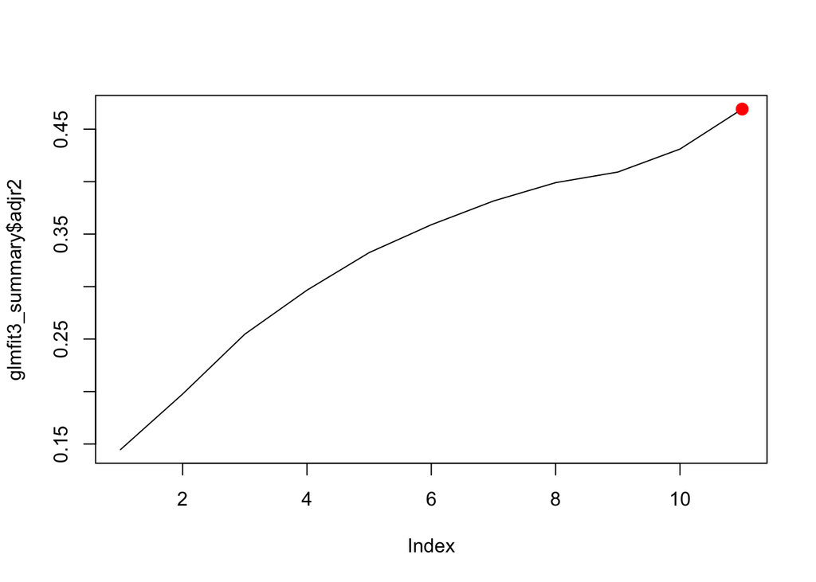

```r
plot(glmfit3_summary$adjr2, type = "l")
nr_predictors <- which.max(glmfit3_summary$adjr2)
points(nr_predictors, glmfit3_summary$adjr2[nr_predictors], col = "red", cex = 2, pch = 20)
```

That is, the model suggests 11 predictors to be included.

Let’s look at $BIC$.

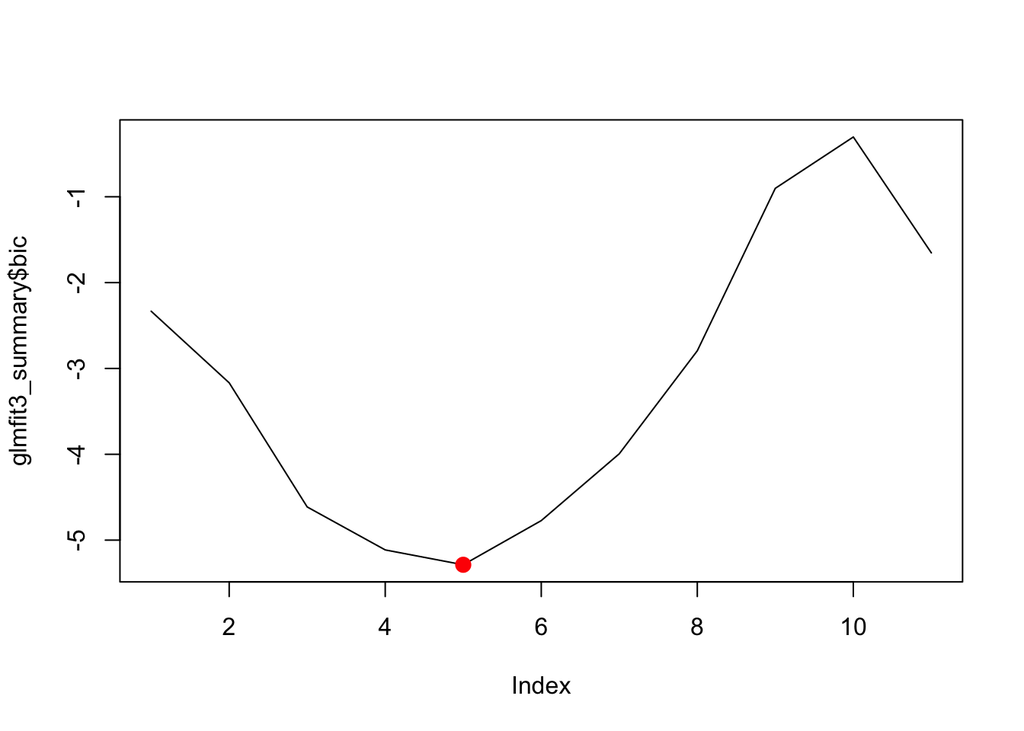

```r
plot(glmfit3_summary$bic, type = "l")
nr_predictors <- which.min(glmfit3_summary$bic)
points(nr_predictors, glmfit3_summary$bic[nr_predictors], col = "red", cex = 2, pch = 20)
```

That is, the model suggests 5 predictors to be included.

$BIC$ is more strict in terms of allowing predictors to enter the model. So let’s look finally to $C_p$:

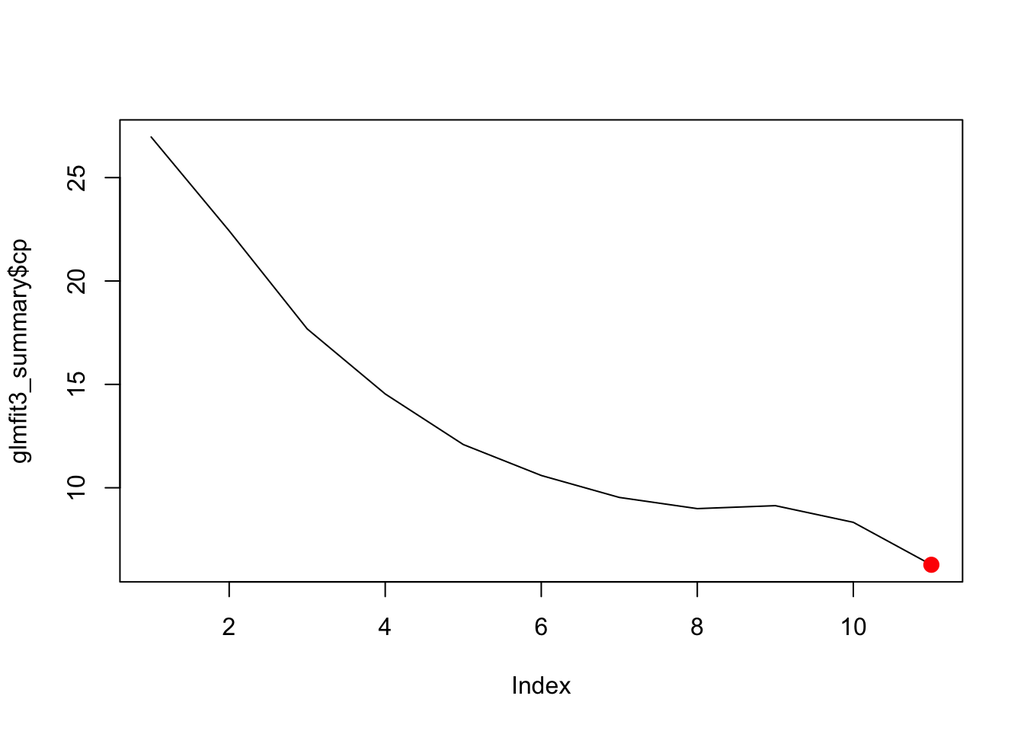

```r
plot(glmfit3_summary$cp, type = "l")
nr_predictors <- which.min(glmfit3_summary$cp)
points(nr_predictors, glmfit3_summary$cp[nr_predictors], col = "red", cex = 2, pch = 20)
```

That is, the model suggests 11 predictors to be included.

Ok, so let’s stick to 11 predictors. These are:

```r
coef(glmfit3, nr_predictors)[-1]
```

```
##             CYBOCS_pre_OBS           CYBOCS_pre_avoid
##                -0.06224996                 0.17374328
##              CDI_S_sum_PRE               SpecificPhob
##                 0.02538470                -0.28903014
## Education_parentUniversity                   OCDonset
##                 0.16559037                -0.06545253
##       contactSelf.referral             medicationnone
##                 0.30622970                -0.56042527
##             medicationSSRI                   symmetry
##                -0.72013943                -0.18428064
##           medication_yesno
##                 0.00000000
```

```r
best_preds <- names(coef(glmfit3, nr_predictors))[-1]  # first is "intercept"
```

### 2.4.2 LM with reduced number of predictors

Ok, now again a linear (logistic) model with the reduced number of predictors. Remember that we work with a train and test sample all the time.

```r
ctrl <- trainControl(method = "repeatedcv",
                     repeats = 10,
                     number = 100)


train_best_preds <- dplyr::select(train_sample, one_of(best_preds), responder_3m_f)
test_best_preds <- dplyr::select(test_sample, one_of(best_preds), responder_3m_f)

expect_that(names(train_best_preds), is_identical_to(names(test_best_preds)))


glmfit4 <- train(factor(responder_3m_f) ~ .,
                 data = train_best_preds,
                 method = "glm",
                 trControl = ctrl)

summary(glmfit4)
```

```
##
## Call:
## NULL
##
## Deviance Residuals:
##      Min        1Q    Median        3Q       Max
## -1.71714  -0.30142   0.00025   0.34144   2.32817
##
## Coefficients: (1 not defined because of singularities)
##                             Estimate Std. Error z value Pr(>|z|)
## (Intercept)                  30.2505  2520.0027   0.012   0.9904
## CYBOCS_pre_OBS               -0.2786     0.2969  -0.938   0.3481
## CYBOCS_pre_avoid              1.4832     0.6810   2.178   0.0294 *
## CDI_S_sum_PRE                 0.1731     0.1816   0.954   0.3402
## SpecificPhob                 -2.1113     1.9011  -1.111   0.2668
## Education_parentUniversity    2.4368     1.2965   1.880   0.0602 .
## OCDonset                     -0.9293     0.4044  -2.298   0.0216 *
## contactSelf.referral          1.9075     4.7989   0.397   0.6910
## medicationnone              -20.5995  2519.9965  -0.008   0.9935
## medicationSSRI              -23.5619  2519.9968  -0.009   0.9925
## symmetry                     -3.0209     1.6768  -1.802   0.0716 .
## medication_yesno                  NA         NA      NA       NA
## ---
## Signif. codes:  0 '***' 0.001 '**' 0.01 '*' 0.05 '.' 0.1 ' ' 1
##
## (Dispersion parameter for binomial family taken to be 1)
##
##     Null deviance: 66.925  on 48  degrees of freedom
## Residual deviance: 29.906  on 38  degrees of freedom
## AIC: 51.906
##
## Number of Fisher Scoring iterations: 17
```

```r
dimnames(summary(glmfit4)$coefficients)[[1]] -> glmfit4_preds

summary(glmfit4)$coefficients %>% as_tibble %>%
  mutate(predictors = glmfit4_preds) %>%
  dplyr::select(predictors, Estimate:`Pr(>|z|)`) ->
  glmfit4_coefs

names(glmfit4_coefs) <- c("predictors", "Estimate", "SE", "z_value", "p_value")


glmfit4_coefs %>%
  mutate_if(is.numeric, funs(round), digits = 2) %>%
  kable
```

| predictors | Estimate | SE | z_value | p_value |
| --- | --- | --- | --- | --- |
| (Intercept) | 30.25 | 2520.00 | 0.01 | 0.99 |
| CYBOCS_pre_OBS | -0.28 | 0.30 | -0.94 | 0.35 |
| CYBOCS_pre_avoid | 1.48 | 0.68 | 2.18 | 0.03 |
| CDI_S_sum_PRE | 0.17 | 0.18 | 0.95 | 0.34 |
| SpecificPhob | -2.11 | 1.90 | -1.11 | 0.27 |
| Education_parentUniversity | 2.44 | 1.30 | 1.88 | 0.06 |
| OCDonset | -0.93 | 0.40 | -2.30 | 0.02 |
| contactSelf.referral | 1.91 | 4.80 | 0.40 | 0.69 |
| medicationnone | -20.60 | 2520.00 | -0.01 | 0.99 |
| medicationSSRI | -23.56 | 2520.00 | -0.01 | 0.99 |
| symmetry | -3.02 | 1.68 | -1.80 | 0.07 |

```r
mod_results$glmfit4 <- save_model_results(glmfit4, test = test_sample)
```

```
##  [1] 0 0 0 0 1 0 0 1 1 0 1 1
## Levels: 0 1
## Confusion Matrix and Statistics
##
##           Reference
## Prediction 0 1
##          0 5 2
##          1 0 5
##
##                Accuracy : 0.8333
##                  95% CI : (0.5159, 0.9791)
##     No Information Rate : 0.5833
##     P-Value [Acc > NIR] : 0.06713
##
##                   Kappa : 0.6757
##  Mcnemar's Test P-Value : 0.47950
##
##             Sensitivity : 1.0000
##             Specificity : 0.7143
##          Pos Pred Value : 0.7143
##          Neg Pred Value : 1.0000
##              Prevalence : 0.4167
##          Detection Rate : 0.4167
##    Detection Prevalence : 0.5833
##       Balanced Accuracy : 0.8571
##
##        'Positive' Class : 0
##
## glm variable importance
##
##                             Overall
## OCDonset                   2.298195
## CYBOCS_pre_avoid           2.177933
## Education_parentUniversity 1.879537
## symmetry                   1.801631
## SpecificPhob               1.110578
## CDI_S_sum_PRE              0.953708
## CYBOCS_pre_OBS             0.938376
## contactSelf.referral       0.397483
## medicationSSRI             0.009350
## medicationnone             0.008174
```

So, the predictors deemed important where:

```r
glmfit4_coefs$predictors
```

```
##  [1] "(Intercept)"                "CYBOCS_pre_OBS"
##  [3] "CYBOCS_pre_avoid"           "CDI_S_sum_PRE"
##  [5] "SpecificPhob"               "Education_parentUniversity"
##  [7] "OCDonset"                   "contactSelf.referral"
##  [9] "medicationnone"             "medicationSSRI"
## [11] "symmetry"
```

Note that the log odds are given by `glm` in R.

```r
mod_results$glmfit4$fit$results$Accuracy
```

```
## [1] 0.6734694
```

However, the accuracy in **test** sample is

```r
mod_results$glmfit4$confusion_matrix
```

```
## Confusion Matrix and Statistics
##
##           Reference
## Prediction 0 1
##          0 5 2
##          1 0 5
##
##                Accuracy : 0.8333
##                  95% CI : (0.5159, 0.9791)
##     No Information Rate : 0.5833
##     P-Value [Acc > NIR] : 0.06713
##
##                   Kappa : 0.6757
##  Mcnemar's Test P-Value : 0.47950
##
##             Sensitivity : 1.0000
##             Specificity : 0.7143
##          Pos Pred Value : 0.7143
##          Neg Pred Value : 1.0000
##              Prevalence : 0.4167
##          Detection Rate : 0.4167
##    Detection Prevalence : 0.5833
##       Balanced Accuracy : 0.8571
##
##        'Positive' Class : 0
##
```

Ok, interesting, we see that some variables are statistically significant (p<.05) now. Precisely, those were statistically significant:

```r
# glmfit4_coefs %>% rename(p_value = `Pr(>|z|)`) -> glmfit4_coefs
# easier name for typing

glmfit4_coefs %>%
  filter(p_value < .05) -> glm_fit4_signif_preds


kable(glm_fit4_signif_preds)
```

| predictors | Estimate | SE | z_value | p_value |
| --- | --- | --- | --- | --- |
| CYBOCS_pre_avoid | 1.4832313 | 0.6810269 | 2.177933 | 0.0294110 |
| OCDonset | -0.9292983 | 0.4043600 | -2.298195 | 0.0215507 |

```r
glm_fit4_signif_preds$predictors
```

```
## [1] "CYBOCS_pre_avoid" "OCDonset"
```

```r
# signif_preds$predictors %in% names(data_class)

important_predictors$bestsubset <- glm_fit4_signif_preds$predictors
```

Ok, interesting.

Let’s look at the significant predictors in some more detail.

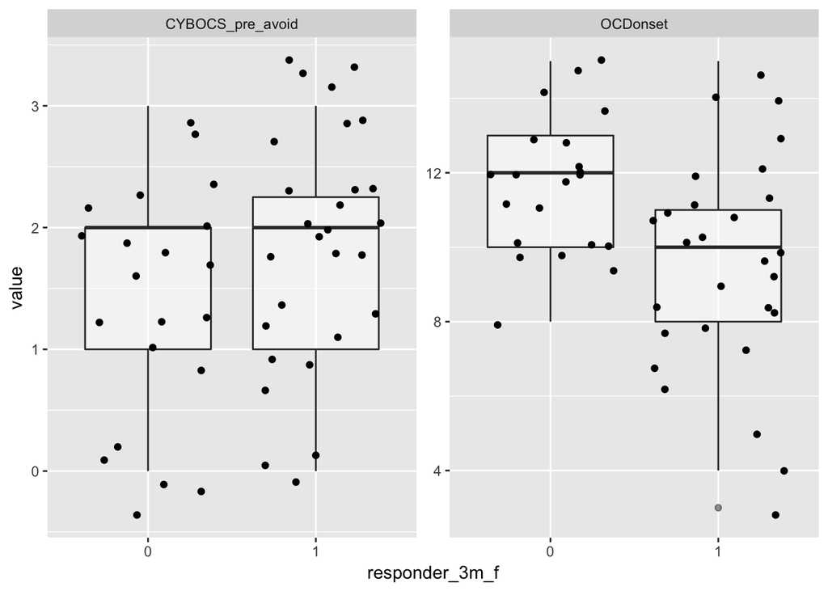

```r
train_sample %>%
  select(one_of(glm_fit4_signif_preds$predictors), responder_3m_f) %>%
  gather(key = predictor, value = value, -responder_3m_f) %>%
  ggplot(aes(x = responder_3m_f, y = value)) +
  geom_boxplot(alpha = .5) +
  geom_jitter() +
  facet_wrap(~predictor, scales = "free")
```

Maybe let’s have a look at the distribution in the sample:

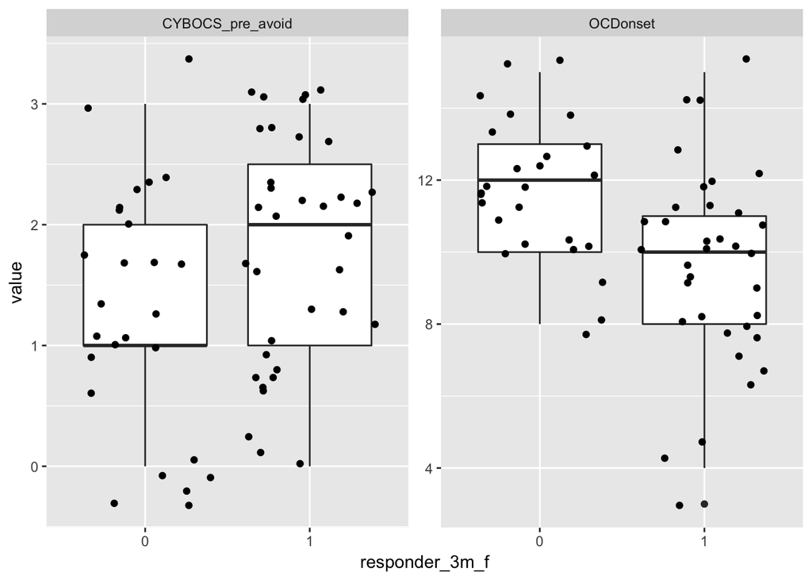

```r
if (length(glm_fit4_signif_preds$predictors) > 0) {
  data_class %>%
    select(one_of(glm_fit4_signif_preds$predictors), responder_3m_f) %>%
    gather(key = variable, value = value, -responder_3m_f) %>%
    ggplot(aes(x = responder_3m_f, y = value)) +
    facet_wrap(~variable, scales = "free") + geom_boxplot() + geom_jitter()
} else {
  message("There are no statistical significant predictors in current model")
}
```

Time to look at different models!

Don’t forget to save results to disk…

```r
expect_equal(length(mod_results), 4)
save(mod_results, file = "data_objects/mod_results.Rda")

expect_gt(length(important_predictors), 0)
save(important_predictors, file = "data_objects/important_predictors.Rda")
```

We did not alter the data, so no need to same them to disk.